# Analysis of Indian General Election Data - 1951-2009

```python
import pandas as pd
import matplotlib.pyplot as plt
import numpy as np
import math
%matplotlib inline
```

```python
df = pd.read_csv("parliament.csv")
```

```python
plt.rcParams["figure.figsize"] = [10,8]
```

```python
df.head()
```

|  | YEAR | STATE | PC | NAME | SEX | PARTY | AGE | CATEGORY | VOTES | ELECTORS | # |
| --- | --- | --- | --- | --- | --- | --- | --- | --- | --- | --- | --- |
| 0 | 1951 | AJMER | AJMER NORTH | JAWALA PRASHAD | NaN | INC | NaN | NaN | 46679 | 162327.0 | 1 |
| 1 | 1951 | AJMER | AJMER NORTH | CHAND KARAN | NaN | BJS | NaN | NaN | 28990 | 162327.0 | 2 |
| 2 | 1951 | AJMER | AJMER NORTH | DINO MAL | NaN | PURP | NaN | NaN | 10778 | 162327.0 | 3 |
| 3 | 1951 | AJMER | AJMER NORTH | BAJORIA BADRIDAS | NaN | IND | NaN | NaN | 6153 | 162327.0 | 4 |
| 4 | 1951 | AJMER | AJMER NORTH | RANG RAJ MEHTA | NaN | IND | NaN | NaN | 4565 | 162327.0 | 5 |

```python
df.describe(include = "all")
```

|  | YEAR | STATE | PC | NAME | SEX | PARTY | AGE | CATEGORY | VOTES | ELECTORS | # |
| --- | --- | --- | --- | --- | --- | --- | --- | --- | --- | --- | --- |
| count | 74930.000000 | 74930 | 74930 | 74930 | 71462 | 74930 | 13505.000000 | 13505 | 74930.000000 | 6.949500e+04 | 74930.000000 |
| unique | NaN | 50 | 973 | 58067 | 2 | 881 | NaN | 3 | NaN | NaN | NaN |
| top | NaN | UTTAR PRADESH | NALGONDA | OM PRAKASH | M | IND | NaN | GEN | NaN | NaN | NaN |
| freq | NaN | 15582 | 575 | 80 | 68349 | 41469 | NaN | 9246 | NaN | NaN | NaN |
| mean | 1989.949473 | NaN | NaN | NaN | NaN | NaN | 45.774972 | NaN | 49700.452969 | 9.573475e+05 | 11.962859 |
| std | 13.981721 | NaN | NaN | NaN | NaN | NaN | 11.923001 | NaN | 94144.950189 | 3.516189e+05 | 30.865537 |
| min | 1951.000000 | NaN | NaN | NaN | NaN | NaN | 25.000000 | NaN | 0.000000 | 1.000000e+00 | 1.000000 |
| 25% | 1984.000000 | NaN | NaN | NaN | NaN | NaN | NaN | NaN | 940.000000 | NaN | 3.000000 |
| 50% | 1991.000000 | NaN | NaN | NaN | NaN | NaN | NaN | NaN | 3535.000000 | NaN | 6.000000 |
| 75% | 1998.000000 | NaN | NaN | NaN | NaN | NaN | NaN | NaN | 45776.750000 | NaN | 12.000000 |
| max | 2009.000000 | NaN | NaN | NaN | NaN | NaN | 99.000000 | NaN | 855543.000000 | 3.103525e+06 | 480.000000 |

We notice that there are 50 states and 973 unique constituencies. From 1951 to 2009 constiuencies were changed many times and hence the large number. Lets look at the unique values.

```python
print df.CATEGORY.unique()
print "\n"
print df.STATE.unique()
print "\n"
print df.PARTY.unique()
print "\n"
```

```
['GEN' 'ST' 'SC']


['AJMER' 'ASSAM' 'BHOPAL' 'BIHAR' 'BILASPUR' 'BOMBAY' 'COORG'
 'HIMACHAL PRADESH' 'HYDERABAD' 'KUTCH' 'MADHYA BHARAT' 'MADHYA PRADESH'
 'MADRAS' 'MANIPUR' 'MYSORE' 'NCT OF DELHI' 'ORISSA'
 'PATIALA AND EAST PUNJAB STATES UNION' 'PUNJAB' 'RAJASTHAN' 'SAURASHTRA'
 'TRAVANCORE COCHIN' 'TRIPURA' 'UTTAR PRADESH' 'VINDHYA PRADESH'
 'WEST BENGAL' 'ANDHRA PRADESH' 'KERALA' 'GUJARAT' 'MAHARASHTRA'
 'A&N ISLANDS' 'CHANDIGARH' 'D&N HAVELI' 'GOA, DAMAN & DIU' 'HARYANA'
 'JAMMU & KASHMIR' 'LAKSHADWEEP' 'NAGALAND' 'PUDUCHERRY' 'TAMIL NADU'
 'ARUNACHAL PRADESH' 'KARNATAKA' 'MEGHALAYA' 'MIZORAM' 'SIKKIM'
 'DAMAN & DIU' 'GOA' 'CHHATTISGARH' 'JHARKHAND' 'UTTARAKHAND']


['INC' 'BJS' 'PURP' 'IND' 'CPI' 'RRP' 'KJD' 'HPP' 'SP' 'KMPP' 'TS' 'APP'
 'HMS' 'KMM' 'JHP' 'FBL(MG)' 'UKS' 'CNSPJP' 'LSS' 'SCF' 'KLP' 'KKP' 'NAT'
 'PWP' 'PDF' 'HSPP' 'FBL(RG)' 'SKP' 'REP' 'TNT' 'CWL' 'JUSP' 'ML' 'GSS'
 'PP' 'AMN' 'HR' 'KNA' 'GP' 'SAD' 'RCPI' 'ZP' 'DCL' 'KJSP' 'SKS' 'RPP' 'CP'
 'KSP' 'TTC' 'TP' 'RSP' 'RSP(UP)' 'UPPP' 'BPI' 'PSP' 'FBM' 'SWA' 'JS' 'HLC'
 'SOC' 'RCP' 'JP' 'NJP' 'FB' 'DMK' 'SL' 'TNP' 'WT' 'AD' 'HLS' 'EIT' 'GL'
 'CPM' 'RPI' 'SSP' 'AHL' 'JKD' 'UGS' 'UGF' 'JKN' 'DNC' 'KEC' 'MUL' 'JAC'
 'NNO' 'PFR' 'ADS' 'ADM' 'FBL' 'BAC' 'TPS' 'NCO' 'RPK' 'MLP' 'TEC' 'BCM'
 'SUC' 'RCI' 'BKD' 'HSD' 'PHJ' 'JKP' 'ISP' 'JAP' 'SHD' 'BRP' 'PBI' 'RSM'
 'VHP' 'MAG' 'LRP' 'SHS' 'RPG' 'MRP' 'UFN' 'UTC' 'RPA' 'KMP' 'MUM' 'IGL'
 'BLD' 'SSD' 'KCP' 'MLO' 'UDF' 'ADK' 'ILP' 'JMD' 'TUS' 'INC(I)' 'JNP'
 'JNP(S)' 'INC(U)' 'BSP' 'PPA' 'IML' 'PPC' 'SJP' 'SCR' 'SPC' 'LKD' 'TDP'
 'BJP' 'ICS' 'ICJ' 'JMM' 'DDP' 'JPP' 'KCJ' 'NND' 'GKC' 'TNC' 'PTC'
 'ICS(SCS)' 'JNP (JP)' 'MCPI' 'MIM' 'LKP' 'LKD (B)' 'JD' 'SOP(L)' 'DLP'
 'VJS' 'IPF' 'BKS' 'BKUS' 'PVP' 'M-COR' 'HJD' 'AMB' 'BLKD' 'LMS' 'DMM'
 'SAD(M)' 'GJP' 'PDL' 'KRS' 'SVP' 'KGP' 'DKP' 'KCM' 'NRP' 'GPI' 'HPI' 'HJP'
 'VBP' 'SHP' 'MPC' 'MNF' 'DP' 'NPC' 'PPI' 'LPI' 'HSS' 'ICJ(TG)' 'PDI' 'LMD'
 'RPI(GG)' 'OPF' 'PMK' 'TMM' 'SAD(B)' 'IGC' 'PNF' 'BJMD' 'PPP' 'PKD'
 'CPI(ML)' 'SRP' 'RIS' 'TRM' 'MPP' 'SLL' 'PWA' 'IJP' 'BMC' 'KDC' 'UPRP'
 'SOP' 'UKD' 'LTP' 'INC(O)' 'GNLF' 'GOL(BG)' 'WBS(BM)' 'LAB(B)' 'NBP' 'MSD'
 'BDLP' 'ADC' 'AGP' 'UMF' 'NAGP' 'URC' 'AJD' 'SLP' 'JD(S)' 'PTCA' 'AJP'
 'SKD' 'DBM' 'ABSP' 'JMS' 'AZP' 'RRP(S)' 'JF' 'LAJM' 'KMS' 'GLP' 'YVP'
 'SLI' 'HSH' 'JD(G)' 'AHF' 'SCP' 'SMP' 'HVP' 'JKMP' 'SJJP' 'RKD' 'SUP'
 'KNP' 'CKN' 'BBP' 'KDP' 'GNP' 'DPI' 'BDP' 'RPPI' 'VPP' 'DPP' 'SRS'
 'RPI(KM)' 'RSD' 'NP' 'NPP' 'DBP' 'RPI(A)' 'BLMD' 'RUD' 'DND' 'PRC'
```

[output cut: 43 more lines]

```
 'SUSP' 'BHPD' 'CGVP' 'GMS' 'RGOP' 'JCGP' 'ABSSP' 'SSBD' 'SGF' 'MJP' 'BNJD'
 'NLHP' 'SVPP' 'RSP(S)' 'VHS' 'NSCP' 'RPIE' 'ADSP' 'HJCBL' 'SMBHP' 'BHBP'
 'AIFB(S)' 'RND' 'JJJKMC' 'AIRP' 'JUP' 'RASAP' 'RASJP' 'NELU' 'VAJP' 'BHC'
 'RRD' 'JKANC' 'RNSP' 'JPC' 'BCDP' 'DGPP' 'BSKRP' 'JVD' 'AJSUP' 'BSA'
 'RASD' 'JHJAM' 'LJVM' 'MMM' 'BSSPA' 'JHJM' 'KTMK' 'BPJP' 'AIJMK' 'NDEP'
 'ICSP' 'BSC' 'BHPP' 'VCK' 'BMM' 'IVD' 'PRSP' 'BJBP' 'LKSP' 'ABHKP' 'AIC'
 'DESEP' 'RP(K)' 'KM' 'MNS' 'STBP' 'ABMP' 'LKSGM' 'SWP' 'JSS' 'PRPI' 'PPIS'
 'BREM' 'BVA' 'LVKP' 'PG' 'RBCP' 'PDA' 'HSPDP' 'MDP' 'ACNC' 'BPC' 'MBP'
 'BVVP' 'YFE' 'AWD' 'AIBS' 'LKJP' 'JBP' 'RALP' 'KS' 'SAMO' 'JHKP' 'KOKD'
 'OMM' 'DMDK' 'DCP' 'ARWP' 'AIDWC' 'ABJP' 'PLP' 'RMGLMP' 'RBD' 'BCP' 'RDSD'
 'SJEP' 'SGPP' 'PNK' 'AIVP' 'ADSMK' 'MAMAK' 'MMKA' 'PKMK' 'DPK' 'KNMK'
 'UMK' 'CDF' 'NMK' 'JBSP' 'RAJUP' 'MADP' 'RMSP' 'PECP' 'MAP' 'MD' 'MMUP'
 'BDBP' 'BUM' 'PDFO' 'JM' 'MKUP' 'BSRD' 'RJPK' 'UNLP' 'RTKP' 'RLP' 'PRBD'
 'BJBCD' 'RSUPRP' 'RYS' 'BAP' 'BSKPB' 'LSVP' 'RWSP' 'IPP' 'RALOP' 'SWPI'
 'BGD' 'JANS' 'RAD' 'MOP' 'APRD' 'NYP' 'MKD' 'RJSD' 'VVS' 'IPFB']
```

A lot of Missing Values in Category and Age. Only 18% values are present.

By further analysis it seems that ages and Category were only recorded from 2004 onwards and all values before that were missing.

We can replace Age by the mean since the SD is only 11years it is a good representative of the Age.

From Wikipedia -

Out of 543 constituencies represented in the Lok Sabha, the lower house India's parliament, 84 (15.47%) are reserved for SC/Dalits and 47 (8.66%) are reserved for ST.

To fill the missing values in Category, I randomly replace the missing values randomly with SC, ST and GEN in the above mentioned ratio.

```python
df['AGE'].fillna((df['AGE'].mean()), inplace=True)

df['CATEGORY'].fillna(pd.Series(np.random.choice(['SC', 'ST', 'GEN'],
                                                      p=[0.1547, 0.0866, 0.7587], size=len(df))),inplace=True)
df['SEX'].fillna("M",inplace=True)

df['ELECTORS'].fillna((df['ELECTORS'].mean()), inplace = True)
```

```python
df.describe(include = "all")
```

|  | YEAR | STATE | PC | NAME | SEX | PARTY | AGE | CATEGORY | VOTES | ELECTORS | # |
| --- | --- | --- | --- | --- | --- | --- | --- | --- | --- | --- | --- |
| count | 74930.000000 | 74930 | 74930 | 74930 | 74930 | 74930 | 74930.000000 | 74930 | 74930.000000 | 7.493000e+04 | 74930.000000 |
| unique | NaN | 50 | 973 | 58067 | 2 | 881 | NaN | 3 | NaN | NaN | NaN |
| top | NaN | UTTAR PRADESH | NALGONDA | OM PRAKASH | M | IND | NaN | GEN | NaN | NaN | NaN |
| freq | NaN | 15582 | 575 | 80 | 71817 | 41469 | NaN | 55949 | NaN | NaN | NaN |
| mean | 1989.949473 | NaN | NaN | NaN | NaN | NaN | 45.774972 | NaN | 49700.452969 | 9.573475e+05 | 11.962859 |
| std | 13.981721 | NaN | NaN | NaN | NaN | NaN | 5.061647 | NaN | 94144.950189 | 3.386265e+05 | 30.865537 |
| min | 1951.000000 | NaN | NaN | NaN | NaN | NaN | 25.000000 | NaN | 0.000000 | 1.000000e+00 | 1.000000 |
| 25% | 1984.000000 | NaN | NaN | NaN | NaN | NaN | 45.774972 | NaN | 940.000000 | 7.228450e+05 | 3.000000 |
| 50% | 1991.000000 | NaN | NaN | NaN | NaN | NaN | 45.774972 | NaN | 3535.000000 | 9.573475e+05 | 6.000000 |
| 75% | 1998.000000 | NaN | NaN | NaN | NaN | NaN | 45.774972 | NaN | 45776.750000 | 1.154100e+06 | 12.000000 |
| max | 2009.000000 | NaN | NaN | NaN | NaN | NaN | 99.000000 | NaN | 855543.000000 | 3.103525e+06 | 480.000000 |

Taken care of missing values This script will reformat all the names to the Format - (First Name Middle Name Last Name)

```python
def redo_names(x):
    n = x.replace(" ","")
    if n.count(",") == 1:
        lname, fname = n.split(',')
        return fname + " " + lname
    elif n.count(",") == 2:
        lname, fname, bname = n.split(",")
        return bname + " " + fname + " "+  lname
    elif n.count(",") == 3:
        return "AJIT KUMAR PANJA" #One off exceptional case
    else:
        return x

df["NAME"] = df["NAME"].map(redo_names)
```

```python
df.head(10)
```

|  | YEAR | STATE | PC | NAME | SEX | PARTY | AGE | CATEGORY | VOTES | ELECTORS | # |
| --- | --- | --- | --- | --- | --- | --- | --- | --- | --- | --- | --- |
| 0 | 1951 | AJMER | AJMER NORTH | JAWALA PRASHAD | M | INC | 45.774972 | GEN | 46679 | 162327.0 | 1 |
| 1 | 1951 | AJMER | AJMER NORTH | CHAND KARAN | M | BJS | 45.774972 | GEN | 28990 | 162327.0 | 2 |
| 2 | 1951 | AJMER | AJMER NORTH | DINO MAL | M | PURP | 45.774972 | GEN | 10778 | 162327.0 | 3 |
| 3 | 1951 | AJMER | AJMER NORTH | BAJORIA BADRIDAS | M | IND | 45.774972 | GEN | 6153 | 162327.0 | 4 |
| 4 | 1951 | AJMER | AJMER NORTH | RANG RAJ MEHTA | M | IND | 45.774972 | GEN | 4565 | 162327.0 | 5 |
| 5 | 1951 | AJMER | AJMER SOUTH | MUKAT BEHARI LAL | M | INC | 45.774972 | GEN | 43082 | 167157.0 | 1 |
| 6 | 1951 | AJMER | AJMER SOUTH | KUMARANAND | M | CPI | 45.774972 | GEN | 25128 | 167157.0 | 2 |
| 7 | 1951 | AJMER | AJMER SOUTH | MADAN SINGH | M | RRP | 45.774972 | ST | 13624 | 167157.0 | 3 |
| 8 | 1951 | ASSAM | AUTONOMOUS DISTS | BONILY KHONGMEN | M | INC | 45.774972 | GEN | 59326 | 360630.0 | 1 |
| 9 | 1951 | ASSAM | AUTONOMOUS DISTS | WILSON READE | M | KJD | 45.774972 | GEN | 32987 | 360630.0 | 2 |

This dataset is now ready for analysis

1) Which year has the most number of candidates?

```python
df.YEAR.value_counts()
```

```
1996    13952
1991     8668
2009     8070
1989     6160
2004     5435
1984     5312
1998     4750
1999     4648
1980     4629
1971     2784
1977     2439
1967     2369
1962     1985
1951     1874
1957     1594
1985      180
1992       81
Name: YEAR, dtype: int64
```

```python
## 2)Breakdown of male and female candidates
df.groupby(['YEAR', 'SEX']).size()
```

```
YEAR  SEX
1951  M       1874
1957  M       1594
1962  F         66
      M       1919
1967  F         67
      M       2302
1971  M       2784
1977  F         70
      M       2369
1980  F        143
      M       4486
1984  F        162
      M       5150
1985  F          9
      M        171
1989  F        198
      M       5962
1991  F        326
      M       8342
1992  F          4
      M         77
1996  F        599
      M      13353
1998  F        274
      M       4476
1999  F        284
      M       4364
2004  F        355
      M       5080
2009  F        556
      M       7514
dtype: int64
```

3) Lets see the progression of sex ratio over Time

```
YEAR
1962    0.033249
1967    0.028282
1977    0.028700
1980    0.030892
1984    0.030497
1985    0.050000
1989    0.032143
1991    0.037610
1992    0.049383
1996    0.042933
1998    0.057684
1999    0.061102
2004    0.065317
2009    0.068897
dtype: float64
```

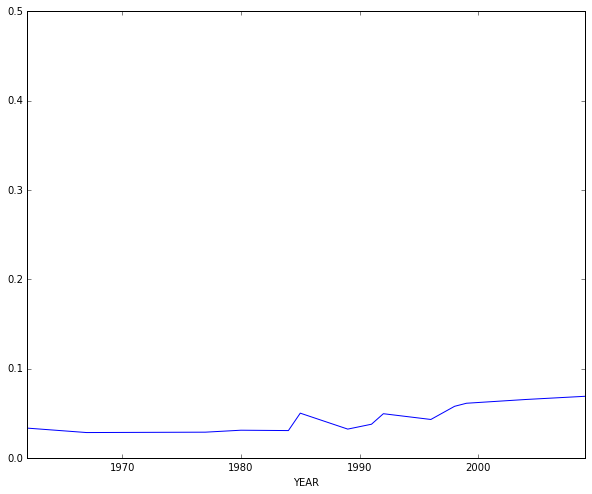

```python
c = df
c = c.groupby(['YEAR', 'SEX']).size()
c = c.unstack('SEX')
c = c.dropna()
print c.F/(c.M+c.F)
(c.F/(c.M+c.F)).plot(ylim = [0,0.5])
```

```python
#Its pathetically low
```

4)Which states has most and least candidates?

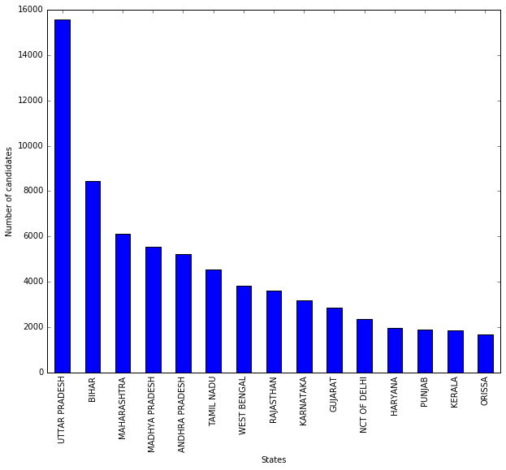

```python
df.STATE.value_counts().head(15).plot(kind = "bar")
plt.ylabel("Number of candidates")
plt.xlabel("States")
```

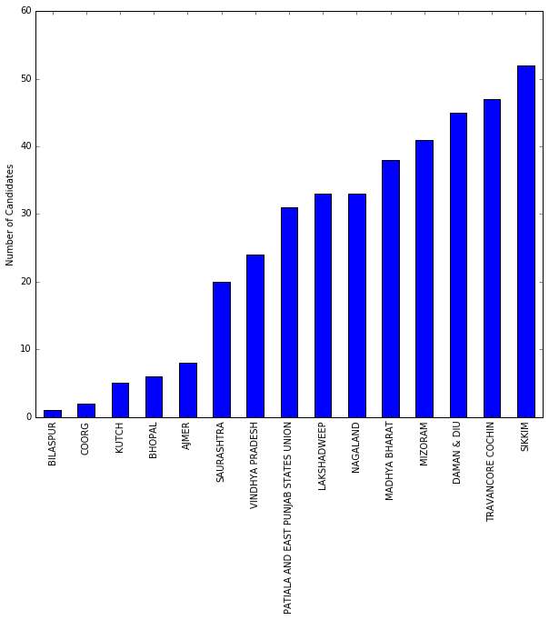

```python
df.STATE.value_counts().tail(15).plot(kind = "bar").invert_xaxis()
plt.ylabel("Number of Candidates")
```

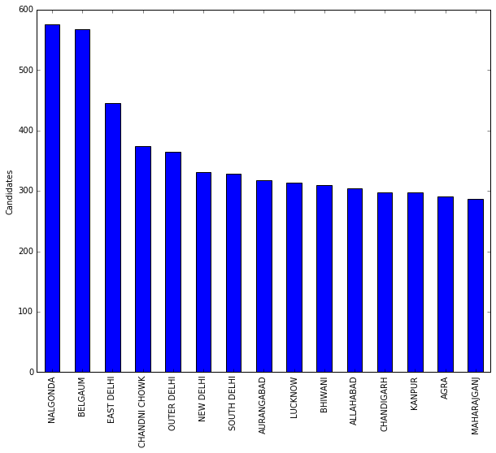

```python
df.PC.value_counts().head(15).plot(kind = "bar")
plt.ylabel("Candidates")
```

6)Oldest and youngest candidates?

```python
c = df
c.sort_values("AGE").head(3)
#Youngest
```

|  | YEAR | STATE | PC | NAME | SEX | PARTY | AGE | CATEGORY | VOTES | ELECTORS | # |
| --- | --- | --- | --- | --- | --- | --- | --- | --- | --- | --- | --- |
| 73230 | 2009 | UTTAR PRADESH | AMETHI | SWAMI NATH | M | IND | 25.0 | GEN | 9642 | 1.431787e+06 | 5 |
| 66056 | 2004 | UTTAR PRADESH | MACHHLISHAHR | ANIL KUMAR ALIAS AWADHESHANAND | M | IND | 25.0 | GEN | 4312 | 9.573475e+05 | 8 |
| 66080 | 2004 | UTTAR PRADESH | MAINPURI | RAKESH KUMAR S/O SHRI SHAITAN SINGH | M | IND | 25.0 | GEN | 966 | 9.573475e+05 | 8 |

```python
c = df
c.sort_values("AGE").tail(3)
#Oldest
```

|  | YEAR | STATE | PC | NAME | SEX | PARTY | AGE | CATEGORY | VOTES | ELECTORS | # |
| --- | --- | --- | --- | --- | --- | --- | --- | --- | --- | --- | --- |
| 67787 | 2009 | BIHAR | HAJIPUR | RAM SUNDAR DAS | M | JD(U) | 88.0 | SC | 246715 | 1.327075e+06 | 1 |
| 63100 | 2004 | KARNATAKA | BIDAR | RAMCHANDRA VEERAPPA | M | BJP | 94.0 | SC | 312838 | 9.573475e+05 | 1 |
| 70704 | 2009 | MAHARASHTRA | DHULE | ARIF AHMED SHAIKH JAFHAR | M | NBNP | 99.0 | GEN | 955 | 1.575225e+06 | 15 |

7)Most common names in history

```python
df.mode()["NAME"][0]
```

```
'OM PRAKASH'
```

8) Most common first name

```python
c = df["NAME"]
c = c.map(lambda x: x.split()[0])
c.mode()[0]
```

```
'RAM'
```

9)Most common last name

```python
c = df["NAME"]
c = c.map(lambda x: x.split()[-1])
c.mode()[0]
```

```
'SINGH'
```

10) Lets see the growth in number of votes every election

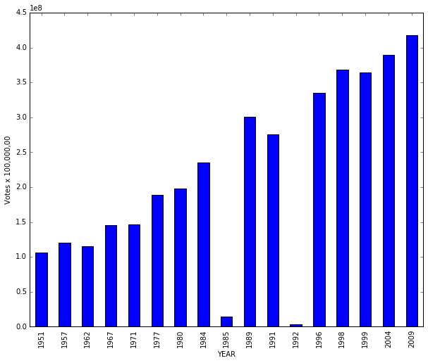

```python
df.groupby(["YEAR"]).sum()["VOTES"].plot(kind = "bar")
plt.ylabel("Votes x 100,000,00")
```

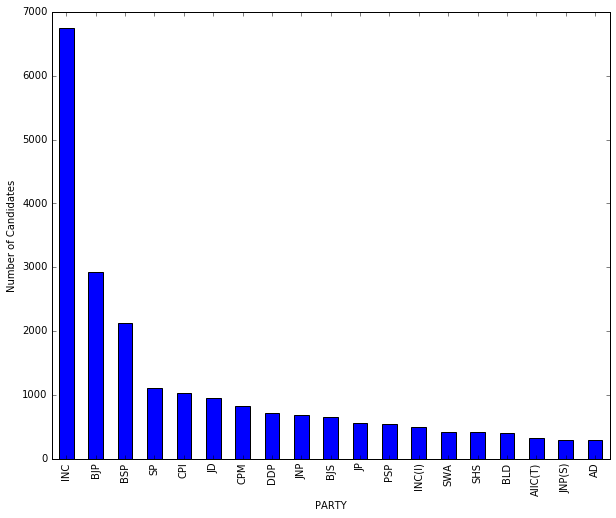

```python
c = df
c.groupby(['PARTY']).size().sort_values(ascending=False).head(20).drop("IND").plot(kind = "bar")
plt.ylabel("Number of Candidates")
```

```python
c = df
print "Number of IND Candidates =", c.groupby(['PARTY']).size()["IND"]
```

```
Number of IND Candidates = 41469
```

[figure not shown]

```python
c = df
c[c.PARTY == "IND"]
c.groupby(["YEAR"]).size().plot(kind = "bar", title = "Number of Independent Candidates by Year")
plt.ylabel("Number of Candidates")
```

```python
c = df
d = df
c = c[c.PARTY == "IND"].groupby(["YEAR"]).size()
d = d[d.PARTY != "IND"].groupby(["YEAR"]).size()
f = (((c/d)*100).to_frame())
f.columns = ["% of Independent Candidates"]
f
```

| YEAR | % of Independent Candidates |
| --- | --- |
| 1951 | 39.746458 |
| 1957 | 51.520913 |
| 1962 | 31.806109 |
| 1967 | 57.618097 |
| 1971 | 68.727273 |
| 1977 | 100.740741 |
| 1980 | 156.738769 |
| 1984 | 249.243918 |
| 1985 | 133.766234 |
| 1989 | 151.736821 |
| 1991 | 174.825618 |
| 1992 | 65.306122 |
| 1996 | 320.747889 |
| 1998 | 67.548501 |
| 1999 | 71.957085 |
| 2004 | 78.196721 |
| 2009 | 90.375088 |

14) Candidates who polled Maximum number of votes every election?

```python
d = (df.loc[(df.groupby(['YEAR'])['VOTES'].idxmax())])
d
```

|  | YEAR | STATE | PC | NAME | SEX | PARTY | AGE | CATEGORY | VOTES | ELECTORS | # |
| --- | --- | --- | --- | --- | --- | --- | --- | --- | --- | --- | --- |
| 462 | 1951 | HYDERABAD | NALGONDA | RAVI NARAYAN REDDY | M | PDF | 45.774972 | GEN | 309162 | 7.295040e+05 | 1 |
| 2256 | 1957 | BOMBAY | BOMBAY CITY CENTRAL | DANGE SHRIPAD AMRIT | M | CPI | 45.774972 | GEN | 323526 | 7.831160e+05 | 1 |
| 4362 | 1962 | MAHARASHTRA | BOMBAY CITY NORTH | V. K. KRISHNA MENON | M | INC | 45.774972 | GEN | 298427 | 7.640160e+05 | 1 |
| 7813 | 1967 | WEST BENGAL | TAMLUK | S. C. SAMANTA | M | BAC | 45.774972 | GEN | 278623 | 5.154150e+05 | 1 |
| 7891 | 1971 | ANDHRA PRADESH | KAKINADA | M. S. SANJEEVI RAO | M | INC | 45.774972 | ST | 313060 | 5.664610e+05 | 1 |
| 10946 | 1977 | BIHAR | HAJIPUR | RAM VILAS PASWAN | M | BLD | 45.774972 | GEN | 469007 | 6.869690e+05 | 1 |
| 17531 | 1980 | WEST BENGAL | DUM DUM | NIREN GHOSH | M | CPM | 45.774972 | ST | 368214 | 9.026110e+05 | 1 |
| 21409 | 1984 | TAMIL NADU | PUDUKKOTTAI | SUNDARARAJ N. | M | INC | 45.774972 | GEN | 426717 | 8.067520e+05 | 1 |
| 23012 | 1985 | ASSAM | GAUHATI | DINESH GOSWAMI | M | IND | 45.774972 | GEN | 428013 | 8.749810e+05 | 1 |
| 23716 | 1989 | BIHAR | HAJIPUR | RAM VILAS PASWAN | M | JD | 45.774972 | GEN | 615129 | 9.774990e+05 | 1 |
| 29430 | 1991 | ANDHRA PRADESH | CUDDAPAH | Y.S. RAJASEKHAR REDDY | M | INC | 45.774972 | GEN | 583953 | 1.138514e+06 | 1 |
| 38017 | 1992 | PUNJAB | GURDASPUR | SUKHBUNS KAUR (W) | F | INC | 45.774972 | GEN | 172391 | 9.640140e+05 | 1 |
| 46216 | 1996 | NCT OF DELHI | OUTER DELHI | KRISHAN LAL SHARMA | M | BJP | 45.774972 | GEN | 701262 | 2.821566e+06 | 1 |
| 54653 | 1998 | NCT OF DELHI | OUTER DELHI | KRISHAN LAL SHARMA | M | BJP | 45.774972 | GEN | 715170 | 2.926563e+06 | 1 |
| 59101 | 1999 | NCT OF DELHI | OUTER DELHI | SAHIB SINGH VERMA | M | BJP | 45.774972 | GEN | 709692 | 3.103525e+06 | 1 |
| 64234 | 2004 | NCT OF DELHI | OUTER DELHI | SAJJAN KUMAR | M | INC | 58.000000 | GEN | 855543 | 9.573475e+05 | 1 |
| 71357 | 2009 | NAGALAND | NAGALAND | C.M. CHANG | M | NPF | 65.000000 | ST | 832224 | 1.321878e+06 | 1 |